# Práctica 2 - Herramientas Exploratorias para Dos o Mas Variables

# Parte 4: Analisis adicional

## ESTATURA-PESO diferenciando por SEXO

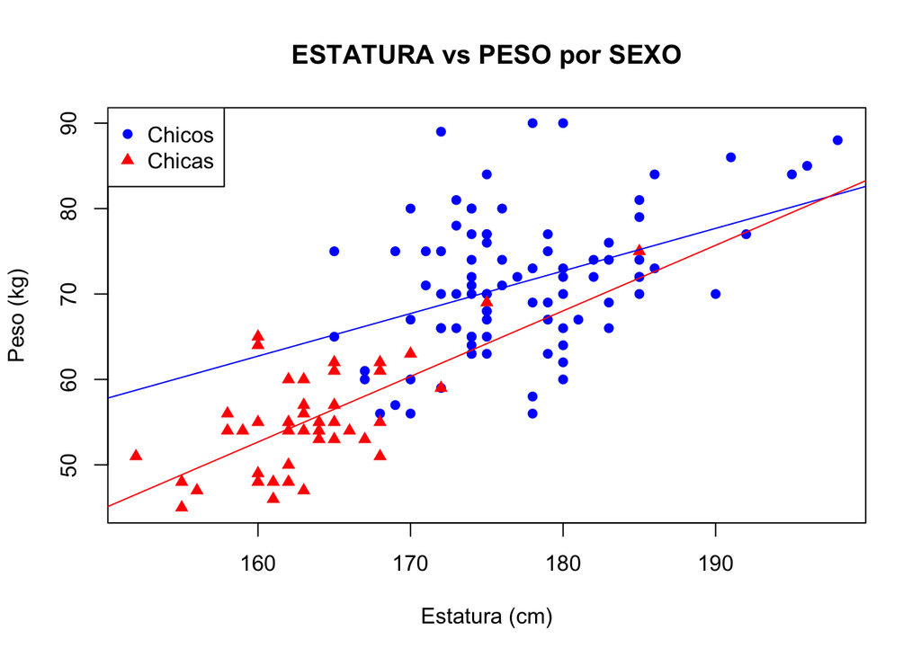

```r
plot(chicos$ESTATURA, chicos$PESO,
     col = "blue", pch = 16,
     xlim = range(datos$ESTATURA, na.rm = TRUE),
     ylim = range(datos$PESO, na.rm = TRUE),
     main = "ESTATURA vs PESO por SEXO",
     xlab = "Estatura (cm)", ylab = "Peso (kg)")
points(chicas$ESTATURA, chicas$PESO, col = "red", pch = 17)
abline(lm(PESO ~ ESTATURA, data = chicos), col = "blue")
abline(lm(PESO ~ ESTATURA, data = chicas), col = "red")
legend("topleft", legend = c("Chicos", "Chicas"),
       col = c("blue", "red"), pch = c(16, 17))
```

```r
cor_total  <- round(cor(datos$ESTATURA, datos$PESO, use = "complete.obs"), 4)
cor_chicos <- round(cor(chicos$ESTATURA, chicos$PESO), 4)
cor_chicas <- round(cor(chicas$ESTATURA, chicas$PESO), 4)

cat("Correlacion total:", cor_total, "\n")
```

```
## Correlacion total: 0.7404
```

```r
cat("Correlacion chicos:", cor_chicos, "\n")
```

```
## Correlacion chicos: 0.4117
```

```r
cat("Correlacion chicas:", cor_chicas, "\n\n")
```

```
## Correlacion chicas: 0.6767
```

```r
cat("La relacion es positiva en ambos grupos pero al separar por sexo la\n")
```

```
## La relacion es positiva en ambos grupos pero al separar por sexo la
```

```r
cat("correlacion baja respecto al total. El sexo actua como variable de\n")
```

```
## correlacion baja respecto al total. El sexo actua como variable de
```

```r
cat("confusion: los chicos son sistematicamente mas altos Y mas pesados,\n")
```

```
## confusion: los chicos son sistematicamente mas altos Y mas pesados,
```

```r
cat("lo que infla la correlacion global.\n")
```

```
## lo que infla la correlacion global.
```

# Parte 5: Analisis con seleccion de datos

## Solo chicas: relacion ESTATURA-PESO

En Statgraphics se usaba el campo Seleccion con SEXO=“chicas”. En R simplemente filtramos.

```r
chicas_ep <- datos[datos$SEXO == "chicas" & !is.na(datos$ESTATURA) & !is.na(datos$PESO), ]
cat("Numero de chicas:", nrow(chicas_ep), "\n")
```

```
## Numero de chicas: 42
```

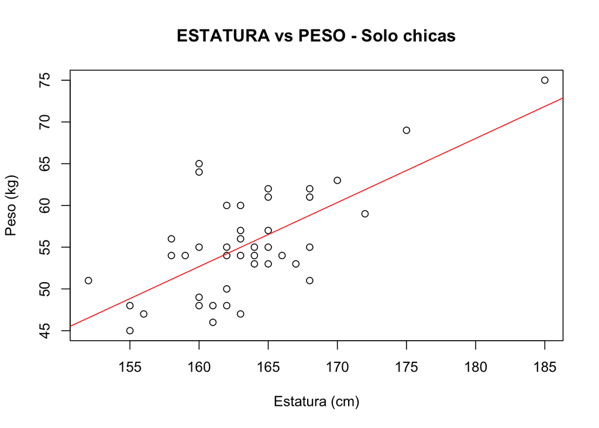

```r
plot(chicas_ep$ESTATURA, chicas_ep$PESO,
     main = "ESTATURA vs PESO - Solo chicas",
     xlab = "Estatura (cm)", ylab = "Peso (kg)")
abline(lm(PESO ~ ESTATURA, data = chicas_ep), col = "red")
```

```r
cat("Covarianza:", round(cov(chicas_ep$ESTATURA, chicas_ep$PESO), 3), "\n")
```

```
## Covarianza: 24.718
```

```r
cat("Correlacion de Pearson:", round(cor(chicas_ep$ESTATURA, chicas_ep$PESO), 4), "\n\n")
```

```
## Correlacion de Pearson: 0.6767
```

```r
cat("Comparacion:\n")
```

```
## Comparacion:
```

```r
cat("  r total: ", cor_total, "\n")
```

```
##   r total:  0.7404
```

```r
cat("  r chicas:", round(cor(chicas_ep$ESTATURA, chicas_ep$PESO), 4), "\n\n")
```

```
##   r chicas: 0.6767
```

```r
cat("La relacion sigue siendo positiva en las chicas pero la correlacion\n")
```

```
## La relacion sigue siendo positiva en las chicas pero la correlacion
```

```r
cat("es algo mas baja que en la muestra completa. Esto confirma que parte\n")
```

```
## es algo mas baja que en la muestra completa. Esto confirma que parte
```

```r
cat("de la correlacion total se debia al efecto del sexo. Analizar\n")
```

```
## de la correlacion total se debia al efecto del sexo. Analizar
```

```r
cat("subconjuntos ayuda a separar efectos y entender mejor los datos.\n")
```

```
## subconjuntos ayuda a separar efectos y entender mejor los datos.
```

# Parte 6: Conclusiones

**Que relaciones hemos encontrado?** La mas clara es ESTATURA-PESO, con una correlacion moderada-fuerte y positiva. El SEXO influye mucho en la ESTATURA y actua como variable de confusion en el analisis conjunto.

**Que variables estan mas relacionadas?** ESTATURA y PESO son las mas correlacionadas entre las cuantitativas. El par SEXO-ESTATURA muestra la diferencia mas evidente a nivel cualitativo-cuantitativo.

**Que tipo de relaciones aparecen?** Las relaciones cuantitativas son lineales positivas donde existen. La relacion SEXO-POLITICA es debil y nominal.

**Que limitaciones tiene el analisis?** La muestra es pequena (131 alumnos de un unico curso), lo que limita la generalizacion. El rango de EDAD es muy estrecho, lo que reduce las correlaciones con esa variable.